# Divvy Bike Share Analysis Report

Zheyan

July 21, 2025

## Introduction

The purpose of this report is to explore **how annual members and customers use Cyclistic bikes differently**. The insights aim to support marketing decisions and identify patterns in ridership behavior.

### Load Data

```r
divvy_2024 <- read_csv("D:/Julianne/Google Data Analytics/Portfolio/Capstone/Data/processed/All_Divvy_Trip_2024_Cleaned.csv")
colnames(divvy_2024)
```

```
##  [1] "trip_id"               "bike_type"             "start_time"
##  [4] "end_time"              "start_station"         "start_station_id"
##  [7] "end_station"           "end_station_id"        "start_lat"
## [10] "start_lng"             "end_lat"               "end_lng"
## [13] "user_type"             "ride_duration_minutes" "day_of_week"
## [16] "weekend_flag"
```

## 1. Average Ride Duration by User Type

To begin the analysis, we explore whether customers and annual members differ in the amount of time they spend on Cyclistic bikes. Understanding this behavior helps identify their **intentions**—whether for leisure or commuting. This section uses a **boxplot** (excluding outliers) to visualize and **compare the typical ride durations between user types**.

```r
average_duration <- divvy_2024 %>%
  group_by(user_type) %>%
  summarise(average_duration = mean(ride_duration_minutes), total_trip_count = n())
head(average_duration)
```

```
## # A tibble: 2 × 3
##   user_type average_duration total_trip_count
##   <chr>                <dbl>            <int>
## 1 customer              24.0          1521552
## 2 member                12.5          2686636
```

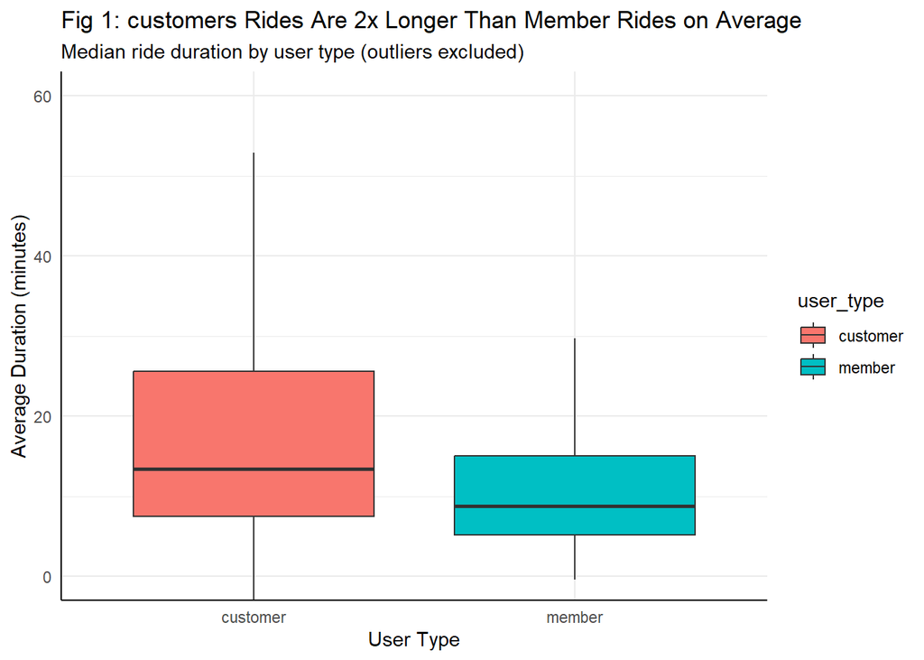

```r
ggplot(divvy_2024, aes(x = user_type, y = ride_duration_minutes, fill = user_type)) +
  geom_boxplot(outlier.shape = NA) +
  coord_cartesian(ylim = c(0, 60)) +
  labs(title = "Fig 1: customers Rides Are 2x Longer Than Member Rides on Average",
       subtitle = "Median ride duration by user type (outliers excluded)",
       y = "Average Duration (minutes)", x = "User Type") +
  theme_minimal() +
  theme(axis.line = element_line(color = "black"))
```

**Insight:** The longer median duration for customerss (after excluding outliers) supports the assumption that customers value experience over efficiency. Members likely ride frequently but briefly, emphasizing convenience. The plot shows a Wider spread for customers duration than member’s average duration, suggesting the customers are more flexible on travel time, while members might be more utility focused.

## 2. Bike Share Peak Hours of Different Users

### Peak Usage Hours by User Type

Understanding when during the day users ride the most is essential for resource allocation and planning. This section analyzes the distribution of ride start times to **identify peak usage hours** for both customers and annual members. The goal is to **differentiate time-based behavior** that reflects each group’s unique motivations.

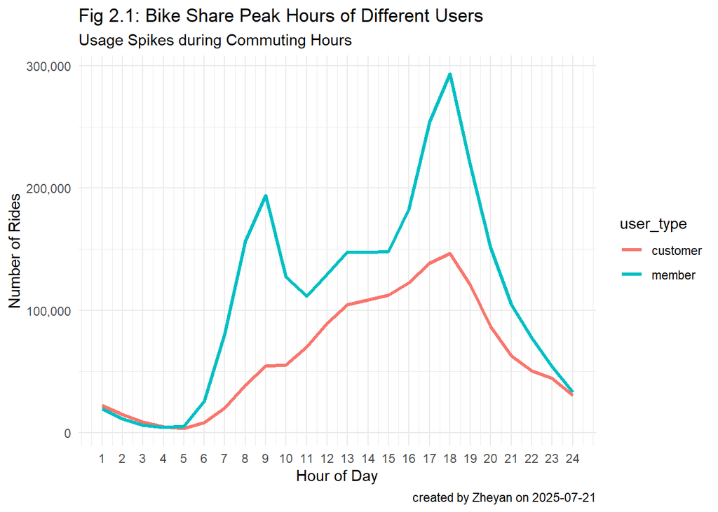

```r
trip_by_hour <- divvy_2024 %>%
  mutate(hour = lubridate::hour(start_time) + 1) %>%
  group_by(user_type, hour) %>%
  summarise(trip_count = n(), .groups = "drop")
ggplot(trip_by_hour, aes(x = hour, y = trip_count, color = user_type)) +
  geom_line(size = 1.2) +
  scale_x_continuous(breaks = 1:24) +
  scale_y_continuous(labels = comma) +
  labs(title = "Fig 2.1: Bike Share Peak Hours of Different Users",
       subtitle = "Usage Spikes during Commuting Hours",
       caption = paste0("created by Zheyan on ", today()),
       x = "Hour of Day", y = "Number of Rides") +
  theme_minimal()
```

By plotting the hourly ride volume, we can observed that member rides cluster around **traditional commuting times** (e.g., 9 AM and 6 PM), while casual rider activity increases during **mid-afternoon** or **daylight hours** (2pm to 6PM).

### Hourly Ride Distribution (Faceted)

To further distinguish **usage patterns by time of day**, break down the hourly ride distribution and visualize it separately for customers and members. Faceted bar charts allow us to examine how **trip frequency**** varies **across each hour** for both groups in parallel. I want to highlights the customers prefer hours and whether members have distinct rush hour peaks.

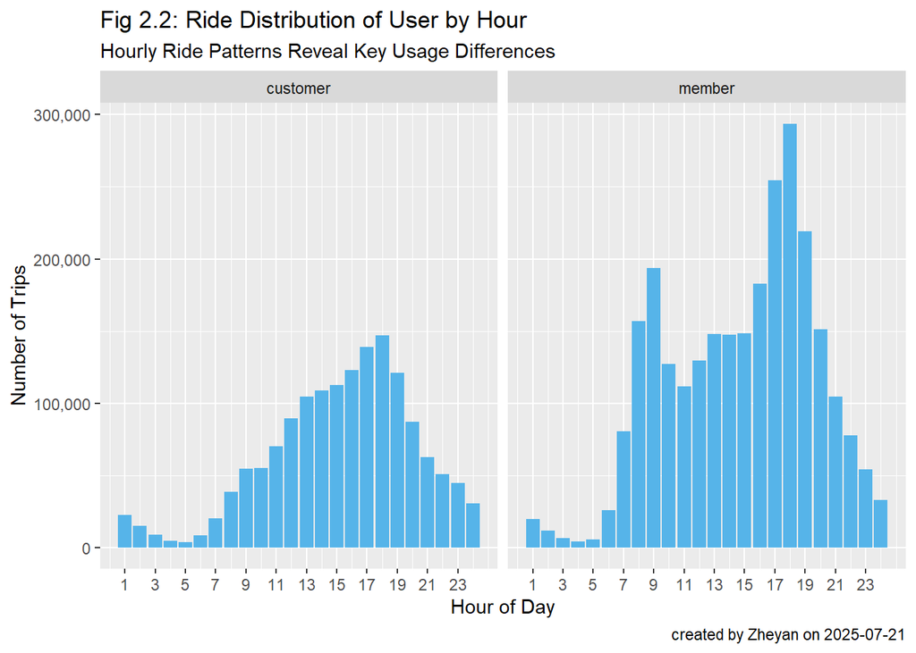

```r
divvy_2024 %>%
  mutate(hour = hour(start_time) + 1) %>%
  group_by(user_type, hour) %>%
  summarise(trip_count = n(), .groups = "drop") %>%
  ggplot(aes(x = hour, y = trip_count)) +
  geom_col(fill = "#56B4E9") +
  facet_wrap(~ user_type) +
  scale_x_continuous(breaks = seq(1, 24, 2)) +
  scale_y_continuous(labels = comma) +
  labs(title = "Fig 2.2: Ride Distribution of User by Hour",
       subtitle = "Hourly Ride Patterns Reveal Key Usage Differences",
       x = "Hour of Day", y = "Number of Trips",
       caption = paste0("created by Zheyan on ", today()))
```

This supports differentiated planning—members need consistent supply across **rush hours**, while casual users require **flexible access on afternoons**. These temporal patterns show clearly distinct ride purposes: **work vs leisure**.

## 3. Ride Activity by Day of Week

Following the analysis of hourly usage patterns, we now examine how **daily trends** further differentiate ride behavior between customers and members. While hourly data revealed that **members cluster around weekday commute hours** and **customers prefer afternoon rides**, this section shifts focus to explore **weekly rhythms**.

By comparing **average ride duration** and **trip counts** across each **day of the week**, we investigate whether members follow a **workday commute cycle**, and whether casual users are more **weekend-oriented**, riding for **leisure or recreation**.

### Average Duration by Day and Rider Type

First, we can explore the average ride duration by day of week for each user type.

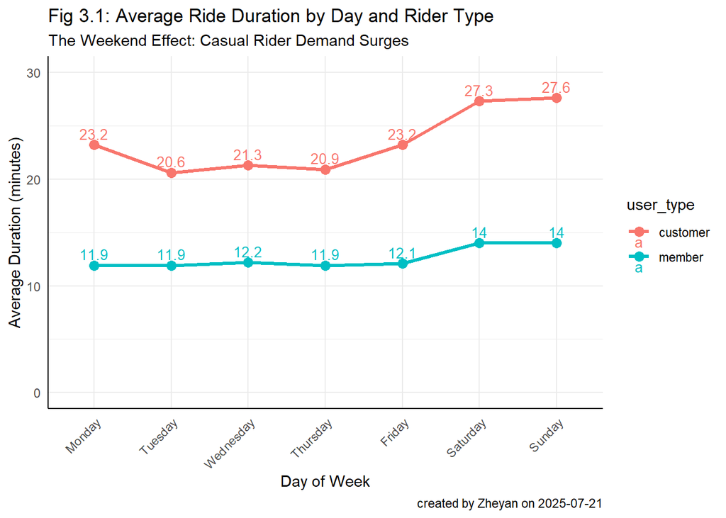

```r
# Create the table
avg_duration_day <- divvy_2024 %>%
  mutate(day_of_week = factor(day_of_week,
         levels = c("Monday", "Tuesday", "Wednesday", "Thursday", "Friday", "Saturday", "Sunday"),
         ordered = TRUE)) %>%
  group_by(user_type, day_of_week) %>%
  summarise(avg_duration = round(mean(ride_duration_minutes), 1), .groups = "drop")

avg_duration_day %>%
  ggplot(aes(x = day_of_week, y = avg_duration, color = user_type, group = user_type)) +
  geom_line(size = 1.2) +
  geom_point(size = 3) +
  geom_text(aes(label = avg_duration), vjust = -0.5, size = 3.5) +  # Correct column name
  scale_y_continuous(limits = c(0, 30)) +
  labs(
    title = "Fig 3.1: Average Ride Duration by Day and Rider Type",
    subtitle = "The Weekend Effect: Casual Rider Demand Surges",
    x = "Day of Week", y = "Average Duration (minutes)",
    caption = paste0("created by Zheyan on ", today())
  ) +
  theme_minimal() +
  theme(
    axis.line = element_line(color = "black"),
    axis.text.x = element_text(angle = 45, hjust = 1)
  )
```

It can be observed that regardless of the day of the week, on average, customers ride for **approximately 2 times longer** than members. We can reasonably assumes that members probably utilize the bike rental service mainly for **commuting purposes**. In contrast, customers rent the bike for a **one or few time uses** and have various **riding purposes**. If we have rider_id, further analysis can be conduct to look at number of rentals per customers vs members.

### Number of Ride by Day of Week

Furthermore, we can validate our assumption regarding the purpose of rides for different users by analyzing the number of trips per day per user.

```r
trip_by_day <- divvy_2024 %>%
  mutate(day_of_week = factor(day_of_week,
         levels = c("Monday", "Tuesday", "Wednesday", "Thursday", "Friday", "Saturday", "Sunday"),
         ordered = TRUE)) %>%
  group_by(user_type, day_of_week) %>%
  summarise(trip_count = n(), .groups = "drop")
top3_trip_day <- trip_by_day %>%
  arrange(user_type, desc(trip_count)) %>%   # sort trip_count descending within user_type
  group_by(user_type) %>%
  slice_max(trip_count, n = 3)  # keep top 3 per user_type
head(top3_trip_day)
```

```
## # A tibble: 6 × 3
## # Groups:   user_type [2]
##   user_type day_of_week trip_count
##   <chr>     <ord>            <int>
## 1 customer  Saturday        317848
## 2 customer  Sunday          266194
## 3 customer  Friday          222575
## 4 member    Wednesday       446905
## 5 member    Tuesday         421424
## 6 member    Thursday        414260
```

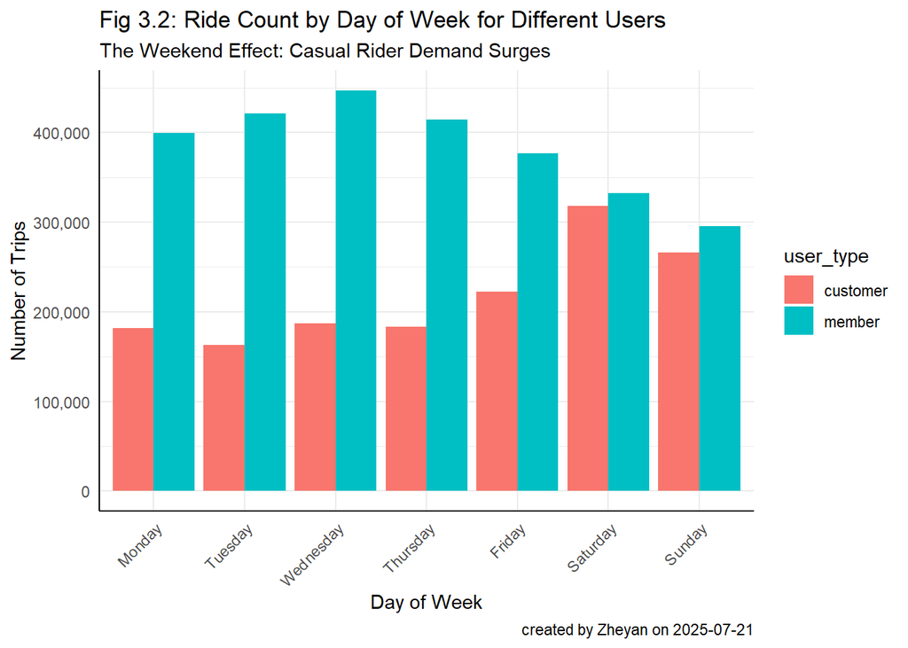

```r
trip_by_day %>%
  ggplot(aes(x = day_of_week, y = trip_count, fill = user_type)) +
  geom_col(position = "dodge") +
  scale_y_continuous(labels = comma) +
  labs(title = "Fig 3.2: Ride Count by Day of Week for Different Users",
       subtitle = "The Weekend Effect: Casual Rider Demand Surges",
       x = "Day of Week", y = "Number of Trips",
       caption = paste0("created by Zheyan on ", today())) +
  theme_minimal() +
  theme(axis.line = element_line(color = "black"),
        axis.text.x = element_text(angle = 45, hjust = 1))
```

The visual data indicates that customers predominantly ride on *days approaching weekend*. Members, on the other hand, tend to ride mostly during *weekdays*. Notably, the ridership shows a **decline** as the weekend approaches. This confirms members are **routine commuters**, while casual users are **weekend explorers**. Targeting promotions based on day-of-week patterns can increase engagement.

## 4. Trip Count by Bike Type

Different rider types may favor different bike types depending on convenience, speed, or comfort. This section compares the **number of rides** taken by each **user group** using each **bike type**—classic bikes, electric bikes, and electric scooters.

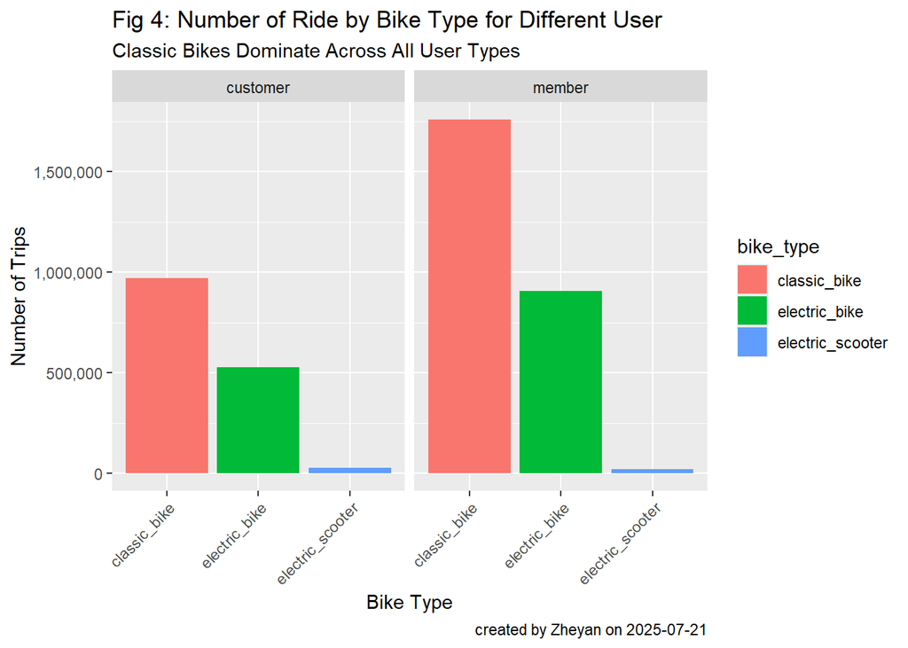

```r
trip_by_bike_type <- divvy_2024 %>%
  group_by(bike_type, user_type) %>%
  summarise(trip_count = n())

ggplot(trip_by_bike_type, aes(x = bike_type, y = trip_count, fill = bike_type)) +
  geom_col() +
  facet_wrap(~ user_type) +
  scale_y_continuous(labels = comma) +
  labs(title = "Fig 4: Number of Ride by Bike Type for Different User",
       subtitle = "Classic Bikes Dominate Across All User Types",
       x = "Bike Type", y = "Number of Trips",
       caption = paste0("created by Zheyan on ", today())) +
  theme(axis.text.x = element_text(angle = 45, hjust = 1))
```

## 5. Average Trip Duration by Bike Type

While ride count tells us about popularity, ride duration can offer insights into how each bike type is used. This section explores **how long, on average, each user type rides different bike types**.

```r
trip_duration_bike_type <- divvy_2024 %>%
  group_by(bike_type, user_type) %>%
  summarise(avg_duration_bike = mean(ride_duration_minutes))

duration_by_bike <- trip_duration_bike_type %>%
    pivot_wider(
    names_from = user_type,
    values_from = avg_duration_bike
  ) %>%
  arrange(bike_type)
print(duration_by_bike)
```

```
## # A tibble: 3 × 3
## # Groups:   bike_type [3]
##   bike_type        customer member
##   <chr>               <dbl>  <dbl>
## 1 classic_bike         29.0  13.4
## 2 electric_bike        15.5  10.8
## 3 electric_scooter     11.3   7.88
```

[figure not shown]

```r
ggplot(trip_duration_bike_type, aes(x = bike_type, y = avg_duration_bike, fill = bike_type)) +
  geom_col() +
  facet_wrap(~ user_type) +
  scale_y_continuous(labels = comma) +
  labs(title = "Fig 5: How Bike Type Affects Ride Duration: Members vs. customers",
       subtitle = "Electric options reduce average ride duration by 40%",
       x = "Bike Type", y = "Average Duration (minutes)",
       caption = paste0("created by Zheyan on ", today())) +
  theme(axis.text.x = element_text(angle = 45, hjust = 1))
```

Customer spend nearly **twice as long** on classic bikes compared to electric bikes (16 min) and scooters (12 min). This suggests **leisure-oriented usage**, such as scenic rides, exercise, or relaxed exploration, where speed is less critical.

## 6. Top Start Stations

Identifying the **top starting stations** helps uncover key locations that serve different types of riders.

### Top Station Across Different Users

Analyze the top 20 start stations for each user group to understand where demand is highest

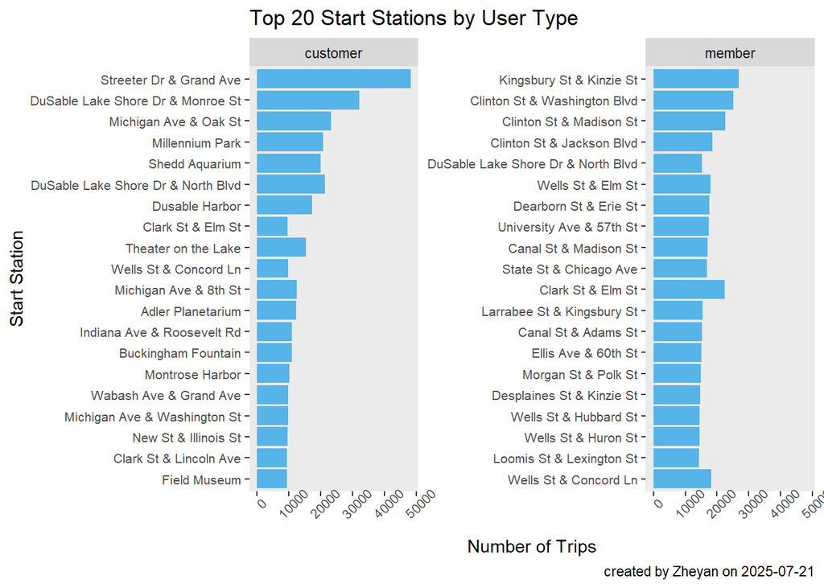

```r
top_stations_by_user <- divvy_2024 %>%
  group_by(user_type, start_station) %>%
  summarise(trip_count = n(), .groups = "drop") %>%
  group_by(user_type) %>%
  slice_max(trip_count, n = 20) %>%
  ungroup()

ggplot(top_stations_by_user, aes(x = reorder(start_station, trip_count), y = trip_count)) +
  geom_col(fill = "#56B4E9") +
  coord_flip() +
  facet_wrap(~ user_type, scales = "free_y") +
  labs(title = "Top 20 Start Stations by User Type",
       x = "Start Station", y = "Number of Trips",
       caption = paste0("created by Zheyan on ", today())) +
  theme(panel.grid.major = element_blank(),
        panel.grid.minor = element_blank(),
        axis.text.y = element_text(size = 8),
        axis.text.x = element_text(size = 8, angle = 45))
```

### Top 50 Station by both customer and Memeber

By comparing these with **member usage** and **total activity**, we can identify **prime locations for outreach** aimed at converting customers into members

```r
top_50_station <- divvy_2024 %>%
  filter(!is.na(start_station)) %>%
  group_by(user_type, start_station) %>%
  summarise(trip_count = n(), .groups = "drop") %>%
  pivot_wider(names_from = user_type, values_from = trip_count, values_fill = 0) %>%
  mutate(total_trips = customer + member) %>%
  arrange(desc(customer)) %>%
  slice_head(n = 50)
head(top_50_station,10)
```

```
## # A tibble: 10 × 4
##    start_station                      customer member total_trips
##    <chr>                                 <int>  <int>       <int>
##  1 Streeter Dr & Grand Ave               48315  13961       62276
##  2 DuSable Lake Shore Dr & Monroe St     32199   9295       41494
##  3 Michigan Ave & Oak St                 23296  13014       36310
##  4 DuSable Lake Shore Dr & North Blvd    21360  15303       36663
##  5 Millennium Park                       20840   9703       30543
##  6 Shedd Aquarium                        20114   4557       24671
##  7 Dusable Harbor                        17264   5990       23254
##  8 Theater on the Lake                   15398  11995       27393
##  9 Michigan Ave & 8th St                 12556   6628       19184
## 10 Adler Planetarium                     12273   4868       17141
```

## Recommendation

- Offer a **cheaper subscription** designed for consumers who are leisurely: the “Weekend Rider” plan,which corresponds with their current **usage patterns**** and grants access for **three individual day passes** or **six single ride passes**. Customers may enjoy **membership benefits** on the days they ride the most with our three-day pass model, which also reduces the **barrier** to **commitment**.
- Offer a **credit system** where customers earn points from rides or referrals, which can be **redeemed for discounts** on annual memberships. This rewards frequent use and **encourages group-based, social riders** to upgrade by benefiting from a **“Refer a Friend” program**.
- Deploy **membership awareness campaigns** at the **top customer-used stations** and during **peak afternoon hours**. Highlight key benefits—like **unlimited rides**, **faster checkout**, and **priority access**.